# Final_Project

To the one of the greatest semester and 謝謝教授

Author

Kuan-Cheng Lee

```r
# Load necessary libraries
#install.packages("stargazer")  # if not already installed
library(stargazer)
library(readxl)
library(dplyr)
library(ggplot2)
library(tidyr)
library(ggplot2)
library(readr)
library(dplyr)
library(nnet)
library(corrplot)
library(tm)
library(wordcloud)
library(corrplot)
```

## Introduction

As generative AI tools like ChatGPT become increasingly integrated into higher education, understanding how students perceive and engage with these technologies has become a critical area of inquiry. This study aims to explore two key questions: first, whether students who use generative AI more frequently tend to trust AI-generated content more; and second, whether students from different academic fields vary in their ethical concerns about the use of generative AI. To examine these questions, survey data were collected from university students, focusing on their frequency of AI use, trust levels, and ethical attitudes. The analysis included hypothesis testing and regression modeling to assess the relationships between these variables and provide insight into students’ perspectives on this rapidly evolving technology.

## Research Question

“How are university students’ self-reported knowledge and ethical concerns about generative AI influenced by their frequency of AI use and their academic field of study?”

```r
# Read the dataset
data <- read.csv("AI_Chatbots_Students_Attitude_Dataset_EN.csv", sep = ",", stringsAsFactors = FALSE)

cat("1")
```

```
1
```

## Description

This project investigates university students’ perceptions, usage, and trust in generative AI tools (like ChatGPT), focusing on how demographic factors, usage frequency, and ethical concerns relate to trust and future intentions.

## Hypothesis

### **Hypothesis 1 (Frequency Knowledge Influence Using AI)**

**H₀ (Null Hypothesis):** There is no relationship between students’ frequency of generative AI use and their self-reported knowledge of AI.  
**H₁ (Alternative Hypothesis):** Students who use generative AI more frequently report higher levels of knowledge about AI.

### **Hypothesis 2 (Ethics and Field of Study)**

**H₀ (Null Hypothesis):** Students from different academic fields do not differ in their ethical concerns about using generative AI.  
**H₁ (Alternative Hypothesis):** Students from different academic fields have significantly different ethical concerns about using generative AI.

## Descriptive Statistics

### Selected Variables:

- **Q1**: Academic level.
- **Q2**: Field of study.
- **Q3**: Gender identity.
- **Q4**: Frequency of generative AI use.
- **Q5.1 – Q5.6**: Perceived benefits of using AI in learning.
- **Q6.1 – Q6.8**: Concerns or perceived risks.
- **Q7.1 – Q7.4**: Trust in AI-generated information.
- **Q8.1 – Q8.5**: Benefit on academic performance or habits.
- **Q9.1 – Q9.5**: Ethical to use AI in future educational tasks.

Factorizing the Dataset Some variables in the dataset are categorical by nature but may initially be read as character strings or numeric values. To enable appropriate analysis and visualization, these columns were converted into factors with meaningful levels. This step helps in treating variables like gender, academic level, and frequency of AI use as categorical variables rather than continuous or plain text.

Q1 (Academic Level): Converted into a binary value with levels between Undergraduate and Graduate.

Q2 (Field of Study): Converted into a factor with levels like Marketing, Finance, Accounting, etc.

Q3 (Gender): Treated as a binary value from male and female into 0 and 1.

Likert-Scale Responses (Q4) (Frequency of Generative AI Use): There are five different frequency from Never to Very Often. In this case, we use Likert-Scale to make the data can present correctly.

Likert-Scale Responses (Q5 to Q9): These responses are ordinal in nature, typically ranging from 1 to 5 (e.g., Strongly Disagree to Strongly Agree). These were converted into ordered factors to reflect their ordinal scale for better statistical interpretation.

This factorization ensures accurate summarization, plotting, and modeling in further stages of analysis.

```r
# Convert categorical variables to factors
#Factorizing categorical columns
data$Q1 <- factor(data$Q1,
                  levels = c('Bachelor', 'Master'),
                  ordered = TRUE)
Q1_likert_scale <- c("Bachelor" = 0, "Master" = 1)
#Q1_likert_scale <- c("Bachelor" = 0, "Master" = 1)


#data$Q2 <- relevel(data$Q2, ref = "Finance")
data$Q2 <- factor(data$Q2,
                  levels = c("Marketing", "Finance", "Accounting", "International Economic Relations", "Economics and Business", "Economics"),
                  ordered = FALSE)
data$Q2 <- relevel(data$Q2, ref = "Finance")

data$Q3 <- factor(data$Q3,
                  levels = c("Male", "Female"),
                  ordered = TRUE)

Q3_likert_scale <- c("Male" = 0, "Female" = 1)


#data$Q3 <- factor(data$Q3, levels = c("Male", "Female"))                   # Gender

# Step 1: Ensure Q4 is an ordered factor
data$Q4 <- factor(data$Q4,
                  levels = c("Never", "Rarely", "Sometimes", "Often", "Very often"),
                  ordered = TRUE)


data$Q4 <- factor(data$Q4,
                  levels = c("Never", "Rarely", "Sometimes", "Often", "Very often"),
                  ordered = TRUE)

Q4_likert_scale <- c("Never"=1, "Rarely"=2, "Sometimes"=3, "Often"=4, "Very often"=5)



# Convert Likert items (Q5.*, Q6.*, Q7.*, Q8.*, Q9.*) to ordered factors
likert_levels <- c("Strongly disagree", "Disagree", "Neutral", "Agree", "Strongly agree")

for (col in grep("^Q[5-9]\\.", names(data), value = TRUE)) {
  data[[col]] <- ordered(data[[col]], levels = likert_levels)
}





# Define Likert scale
likert_scale <- c("Strongly Disagree"=1, "Disagree"=2, "Neutral"=3, "Agree"=4, "Strongly Agree"=5)

# Optional: Check structure
str(data)
```

```
'data.frame':   159 obs. of  34 variables:
 $ Timestamp: chr  "5.14.2023 21:22:19" "5.15.2023 8:45:52" "5.15.2023 9:54:15" "5.15.2023 15:17:41" ...
 $ Q1       : Ord.factor w/ 2 levels "Bachelor"<"Master": 2 1 1 1 1 1 1 2 1 1 ...
 $ Q2       : Factor w/ 6 levels "Finance","Marketing",..: 4 NA 4 4 4 4 4 6 6 2 ...
 $ Q3       : Ord.factor w/ 2 levels "Male"<"Female": 2 2 2 2 2 1 1 1 1 2 ...
 $ Q4       : Ord.factor w/ 5 levels "Never"<"Rarely"<..: 4 3 2 2 3 2 3 2 3 4 ...
 $ Q5.1     : Ord.factor w/ 5 levels "Strongly disagree"<..: 4 2 3 4 4 NA 3 2 3 4 ...
 $ Q5.2     : Ord.factor w/ 5 levels "Strongly disagree"<..: 4 4 3 4 4 4 4 4 4 2 ...
 $ Q5.3     : Ord.factor w/ 5 levels "Strongly disagree"<..: NA 2 3 4 3 4 4 4 4 3 ...
 $ Q5.4     : Ord.factor w/ 5 levels "Strongly disagree"<..: NA NA 2 2 2 2 3 3 3 NA ...
 $ Q5.5     : Ord.factor w/ 5 levels "Strongly disagree"<..: 4 3 3 4 4 4 3 2 3 3 ...
 $ Q5.6     : Ord.factor w/ 5 levels "Strongly disagree"<..: 3 4 4 4 4 NA NA NA NA 4 ...
 $ Q6.1     : Ord.factor w/ 5 levels "Strongly disagree"<..: 4 NA 3 NA 4 4 4 NA NA 4 ...
 $ Q6.2     : Ord.factor w/ 5 levels "Strongly disagree"<..: NA 3 3 3 4 4 4 NA NA 3 ...
 $ Q6.3     : Ord.factor w/ 5 levels "Strongly disagree"<..: 3 4 4 4 4 3 3 NA NA 3 ...
```

[output cut: 20 more lines]

```r
cat("2")
```

```
2
```

```r
# --------------------------------------
# 1. Demographics
# --------------------------------------
# Q1: Level of education
cat("Education Levels:\n")
```

```
Education Levels:
```

```r
print(table(data$Q1))
```

```
Bachelor   Master
     128        3
```

```r
data$Q1_likert <- Q1_likert_scale[as.character(data$Q1)]
#print(prop.table(table(data$Q1)))
#par(mfrow=c(1,1))  # Reset for the each bar chart

# Q2: Field of study
cat("\nField of Study:\n")
```

```
Field of Study:
```

```r
print(table(data$Q2))
```

```
                         Finance                        Marketing
                              23                               28
                      Accounting International Economic Relations
                              17                               14
          Economics and Business                        Economics
                              12                                2
```

```r
#par(mfrow=c(1,1))  # Reset for the each bar chart

# Gender Distribution (Q3)
cat("\nGender Distribution:\n")
```

```
Gender Distribution:
```

```r
print(table(data$Q3))  # Frequency of each gender
```

```
  Male Female
    22    108
```

```r
data$Q3_likert <- Q3_likert_scale[as.character(data$Q3)]
#barplot(table(data$Q3), main = "Gender Distribution", col = "lightgreen")
#par(mfrow=c(1,1))  # Reset for the each bar chart

names(data)
```

```
 [1] "Timestamp" "Q1"        "Q2"        "Q3"        "Q4"        "Q5.1"
 [7] "Q5.2"      "Q5.3"      "Q5.4"      "Q5.5"      "Q5.6"      "Q6.1"
[13] "Q6.2"      "Q6.3"      "Q6.4"      "Q6.5"      "Q6.6"      "Q6.7"
[19] "Q6.8"      "Q7.1"      "Q7.2"      "Q7.3"      "Q7.4"      "Q8.1"
[25] "Q8.2"      "Q8.3"      "Q8.4"      "Q8.5"      "Q9.1"      "Q9.2"
[31] "Q9.3"      "Q9.4"      "Q9.5"      "Q10"       "Q1_likert" "Q3_likert"
```

```r
cat("3")
```

```
3
```

### General Visualizations

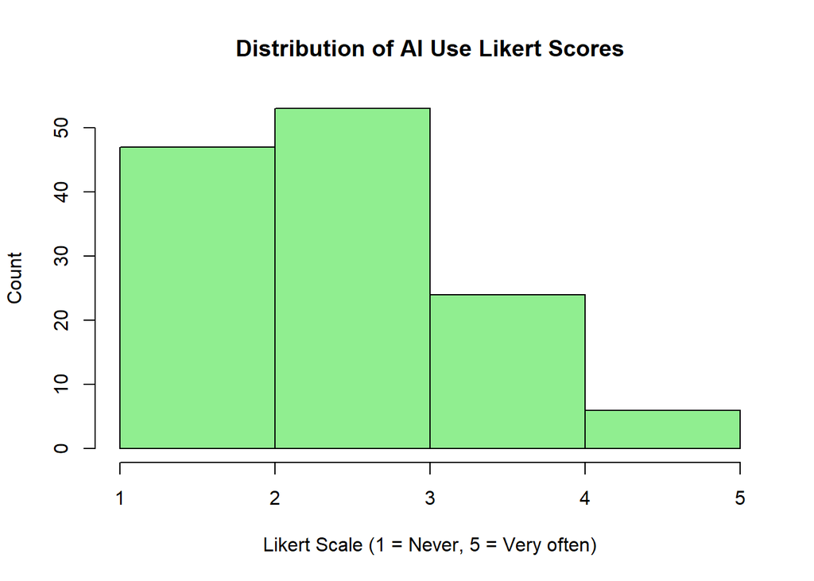

```r
# Create a new numeric variable using the mapping
data$Q4_likert <- Q4_likert_scale[as.character(data$Q4)]
hist(data$Q4_likert,
     breaks = 5,
     col = "lightgreen",
     main = "Distribution of AI Use Likert Scores",
     xlab = "Likert Scale (1 = Never, 5 = Very often)",
     ylab = "Count")
```

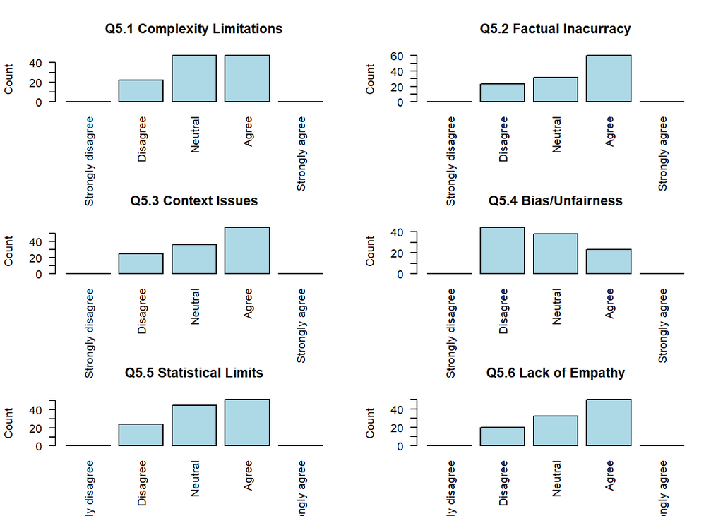

```r
# --------------------------------------
# 3. Trust in AI - Q5.1 to Q5.6
# --------------------------------------

# Frequency of AI Use (Q5)
knowledge_items <- grep("^Q5\\.", names(data), value = TRUE)

# Generate the graph for each sub questions
par(mfrow=c(3,2))  # two rows and three columns

labels <- c(
  "Q5.1" = "Q5.1 Complexity Limitations",
  "Q5.2" = "Q5.2 Factual Inacurracy",
  "Q5.3" = "Q5.3 Context Issues",
  "Q5.4" = "Q5.4 Bias/Unfairness",
  "Q5.5" = "Q5.5 Statistical Limits",
  "Q5.6" = "Q5.6 Lack of Empathy"
)


for (item in knowledge_items) {

  barplot(table(data[[item]]),
          main = labels[item],
          col = "lightblue",
          ylab = "Count",
          las = 2)

}
```

```r
par(mfrow=c(1,1))  # Reset for the each bar chart


# --------------------------------------
# 5. Ethical Concerns - Q7.* and Q9.*
# --------------------------------------
#
ethics_items <- grep("^Q7\\.|^Q9\\.", names(data), value = TRUE)

likert_scale <- c("Strongly Disagree"=1, "Disagree"=2, "Neutral"=3, "Agree"=4, "Strongly Agree"=5)

data_numeric <- data %>%
  mutate(across(all_of(ethics_items), ~ likert_scale[.])) %>%
  mutate(ethics_index = rowMeans(select(., all_of(ethics_items)), na.rm = TRUE))

cat("Summary of Ethical Concern Items:\n")
```

```
Summary of Ethical Concern Items:
```

```r
print(summary(data_numeric[ethics_items]))
```

```
      Q7.1            Q7.2            Q7.3           Q7.4            Q9.1
 Min.   :2.000   Min.   :2.000   Min.   :2.00   Min.   :2.000   Min.   :2.000
 1st Qu.:3.000   1st Qu.:2.000   1st Qu.:2.00   1st Qu.:3.000   1st Qu.:3.000
 Median :3.000   Median :3.000   Median :3.00   Median :4.000   Median :3.000
 Mean   :3.092   Mean   :3.108   Mean   :3.12   Mean   :3.292   Mean   :3.352
 3rd Qu.:4.000   3rd Qu.:4.000   3rd Qu.:4.00   3rd Qu.:4.000   3rd Qu.:4.000
 Max.   :4.000   Max.   :4.000   Max.   :4.00   Max.   :4.000   Max.   :4.000
 NA's   :50      NA's   :57      NA's   :59     NA's   :70      NA's   :37
      Q9.2            Q9.3            Q9.4            Q9.5
 Min.   :2.000   Min.   :2.000   Min.   :2.000   Min.   :2.000
 1st Qu.:3.000   1st Qu.:3.000   1st Qu.:3.000   1st Qu.:3.000
 Median :4.000   Median :3.000   Median :3.000   Median :3.000
 Mean   :3.422   Mean   :3.208   Mean   :3.322   Mean   :3.133
 3rd Qu.:4.000   3rd Qu.:4.000   3rd Qu.:4.000   3rd Qu.:4.000
 Max.   :4.000   Max.   :4.000   Max.   :4.000   Max.   :4.000
 NA's   :43      NA's   :34      NA's   :41      NA's   :46
```

```r
cat("\nEthics Index Summary:\n")
```

```
Ethics Index Summary:
```

```r
print(summary(data_numeric$ethics_index))
```

```
   Min. 1st Qu.  Median    Mean 3rd Qu.    Max.    NA's
  2.000   3.000   3.183   3.221   3.444   4.000      29
```

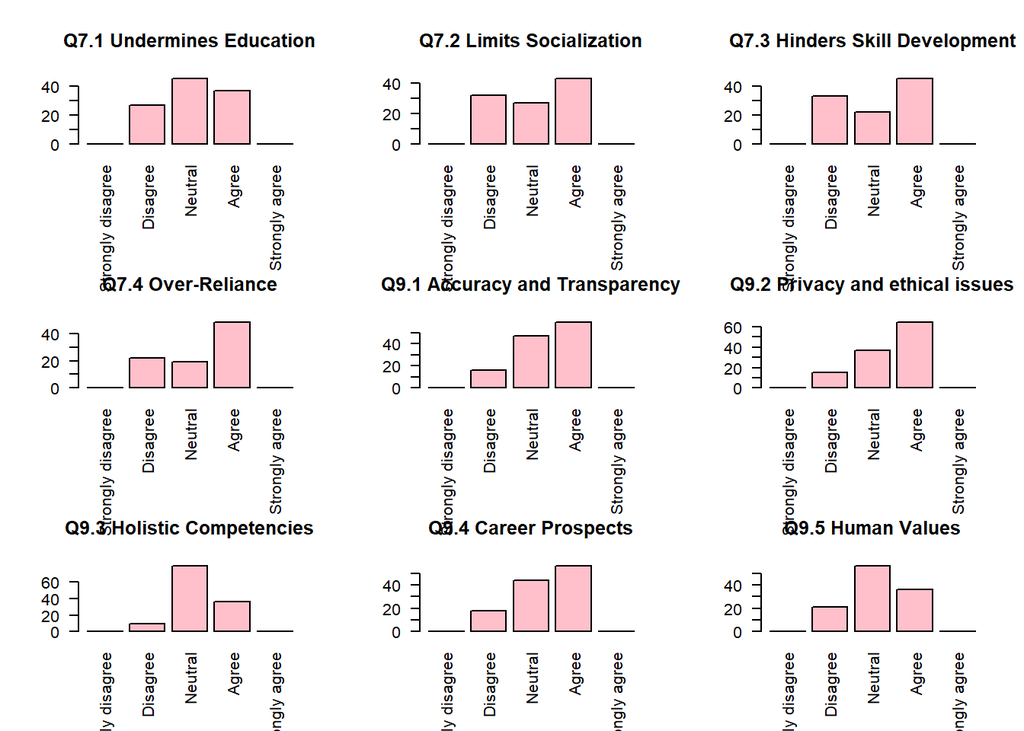

```r
par(mfrow = c(3, 3))  # layout for multiple plots


labels <- c(
  "Q7.1" = "Q7.1 Undermines Education",
  "Q7.2" = "Q7.2 Limits Socialization",
  "Q7.3" = "Q7.3 Hinders Skill Development",
  "Q7.4" = "Q7.4 Over-Reliance",
  "Q9.1" = "Q9.1 Accuracy and Transparency",
  "Q9.2" = "Q9.2 Privacy and ethical issues",
  "Q9.3" = "Q9.3 Holistic Competencies",
  "Q9.4" = "Q9.4 Career Prospects",
  "Q9.5" = "Q9.5 Human Values"
)

for (item in ethics_items) {

  barplot(table(data[[item]]),
          main = labels[item],
          col = "pink",
          las = 2)
}
```

```r
par(mfrow = c(1, 1))  # reset layout



# --------------------------------------
# 6. Ethical Concerns - Q8.1 to Q8.5
# --------------------------------------
#


benefit_items <- grep("^Q8\\.", names(data), value = TRUE)

likert_scale <- c("Strongly Disagree"=1, "Disagree"=2, "Neutral"=3, "Agree"=4, "Strongly Agree"=5)

data_numeric <- data %>%
  mutate(across(all_of(benefit_items), ~ likert_scale[.])) %>%
  mutate(benefit_index = rowMeans(select(., all_of(benefit_items)), na.rm = TRUE))

cat("Summary of Ethical Concern Items:\n")
```

```
Summary of Ethical Concern Items:
```

```r
print(summary(data_numeric[benefit_items]))
```

```
      Q8.1            Q8.2            Q8.3            Q8.4            Q8.5
 Min.   :2.000   Min.   :2.000   Min.   :2.000   Min.   :2.000   Min.   :2.00
 1st Qu.:4.000   1st Qu.:4.000   1st Qu.:4.000   1st Qu.:3.000   1st Qu.:3.00
 Median :4.000   Median :4.000   Median :4.000   Median :3.000   Median :3.00
 Mean   :3.721   Mean   :3.699   Mean   :3.693   Mean   :3.243   Mean   :3.35
 3rd Qu.:4.000   3rd Qu.:4.000   3rd Qu.:4.000   3rd Qu.:4.000   3rd Qu.:4.00
 Max.   :4.000   Max.   :4.000   Max.   :4.000   Max.   :4.000   Max.   :4.00
 NA's   :55      NA's   :56      NA's   :58      NA's   :44      NA's   :42
```

```r
cat("\nEthics Index Summary:\n")
```

```
Ethics Index Summary:
```

```r
print(summary(data_numeric$benefit_index))
```

```
   Min. 1st Qu.  Median    Mean 3rd Qu.    Max.    NA's
  2.200   3.200   3.600   3.515   4.000   4.000      32
```

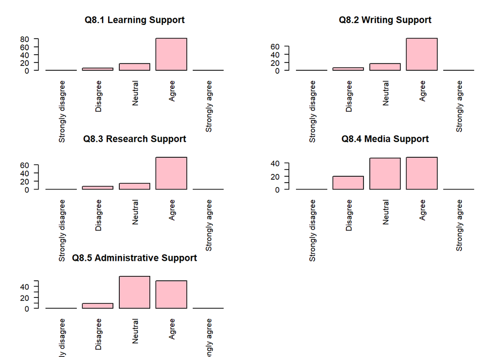

```r
par(mfrow = c(3, 2))  # layout for multiple plots


labels <- c(
  "Q8.1" = "Q8.1 Learning Support",
  "Q8.2" = "Q8.2 Writing Support",
  "Q8.3" = "Q8.3 Research Support",
  "Q8.4" = "Q8.4 Media Support",
  "Q8.5" = "Q8.5 Administrative Support"
)

for (item in benefit_items) {

  barplot(table(data[[item]]),
          main = labels[item],
          col = "pink",
          las = 2)
}

par(mfrow = c(1, 1))  # reset layout
```

```r
cat("4")
```

```
4
```

## Hypothesis Testing

### Model Comparisons

The analysis included four linear regression models to test the study’s hypotheses.

The resulting p-values for each model were as follows:

- **Model 1:** 0.7718
- **Model 2:** 0.1848
- **Model 3:** 0.8886
- **Model 4:** 0.0295

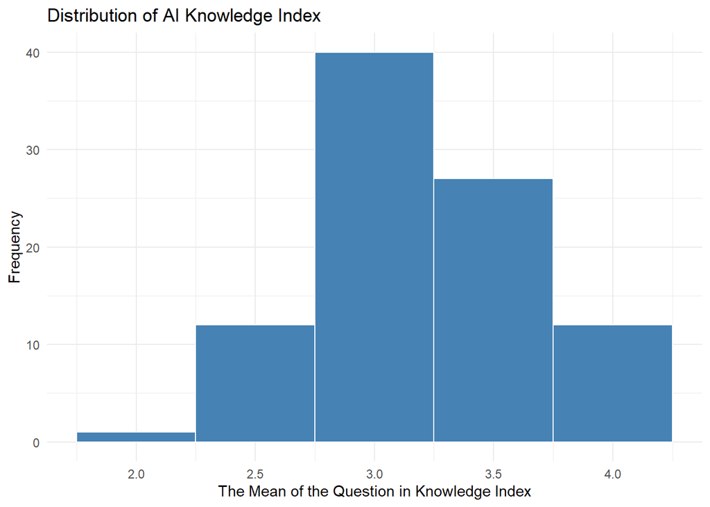

```r
model_data <- data %>%
  # Recode Likert items
  mutate(across(c(starts_with("Q5."), starts_with("Q7."), starts_with("Q8."), starts_with("Q9.")), ~ likert_scale[.])) %>%

  # Create indices
  mutate(
    knowledge_index = rowMeans(select(., starts_with("Q5.")), na.rm = TRUE),
    ethics_index = rowMeans(select(., matches("^Q7\\.|^Q9\\.")), na.rm = TRUE),
    benefit_index = rowMeans(select(., starts_with("Q8.")), na.rm = TRUE),
    Q1_likert_index = rowMeans(select(., starts_with("Q1.")), na.rm = TRUE),
    Q3_likert_index = rowMeans(select(., starts_with("Q3.")), na.rm = TRUE),
    Q4_likert_index = rowMeans(select(., starts_with("Q4.")), na.rm = TRUE)
  ) %>%

  # Select modeling variables
  select(knowledge_index, ethics_index, benefit_index, Q1_likert, Q2, Q3_likert, Q4_likert) %>%
  na.omit()
#ata$Q2 <- relevel(data$Q2, ref = "Finance")

# Histogram for knowledge_index2
ggplot(model_data, aes(x = knowledge_index)) +
  geom_histogram(binwidth = 0.5, fill = "steelblue", color = "white") +
  labs(title = "Distribution of AI Knowledge Index",
       x = "The Mean of the Question in Knowledge Index",
       y = "Frequency") +
  theme_minimal()
```

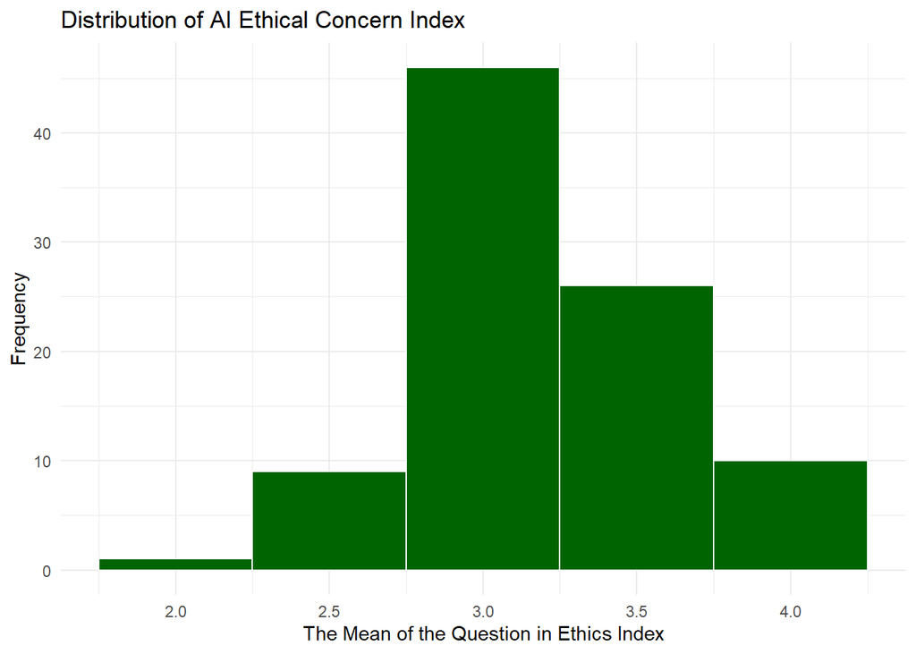

```r
# Histogram for ethics_index2
ggplot(model_data, aes(x = ethics_index)) +
  geom_histogram(binwidth = 0.5, fill = "darkgreen", color = "white") +
  labs(title = "Distribution of AI Ethical Concern Index",
       x = "The Mean of the Question in Ethics Index",
       y = "Frequency") +
  theme_minimal()
```

```r
# 2. Fit models using the same dataset
model1 <- lm(knowledge_index ~ Q4_likert, data = model_data)
model2 <- lm(ethics_index ~ Q2, data = model_data)
model3 <- lm(knowledge_index ~ Q4_likert + Q1_likert + Q3_likert + benefit_index, data = model_data)
model4 <- lm(ethics_index ~ Q2 + Q1_likert + Q3_likert + benefit_index, data = model_data)



summary(model1)
```

```
Call:
lm(formula = knowledge_index ~ Q4_likert, data = model_data)

Residuals:
     Min       1Q   Median       3Q      Max
-1.23122 -0.23122 -0.04251  0.28347  0.79817

Coefficients:
            Estimate Std. Error t value Pr(>|t|)
(Intercept)  3.26062    0.15730  20.729   <2e-16 ***
Q4_likert   -0.01470    0.05052  -0.291    0.772
---
Signif. codes:  0 '***' 0.001 '**' 0.01 '*' 0.05 '.' 0.1 ' ' 1

Residual standard error: 0.4403 on 90 degrees of freedom
Multiple R-squared:  0.0009396, Adjusted R-squared:  -0.01016
F-statistic: 0.08464 on 1 and 90 DF,  p-value: 0.7718
```

```r
summary(model2)
```

```
Call:
lm(formula = ethics_index ~ Q2, data = model_data)

Residuals:
     Min       1Q   Median       3Q      Max
-1.13413 -0.24005 -0.02524  0.26087  0.86587

Coefficients:
                                    Estimate Std. Error t value Pr(>|t|)
(Intercept)                         3.150242   0.082620  38.129   <2e-16 ***
Q2Marketing                         0.077490   0.113422   0.683   0.4963
Q2Accounting                       -0.016115   0.126734  -0.127   0.8991
Q2International Economic Relations  0.003694   0.141101   0.026   0.9792
Q2Economics and Business            0.341822   0.141101   2.423   0.0175 *
Q2Economics                        -0.066908   0.292106  -0.229   0.8194
---
Signif. codes:  0 '***' 0.001 '**' 0.01 '*' 0.05 '.' 0.1 ' ' 1

Residual standard error: 0.3962 on 86 degrees of freedom
Multiple R-squared:  0.08237,   Adjusted R-squared:  0.02902
F-statistic: 1.544 on 5 and 86 DF,  p-value: 0.1848
```

```r
summary(model3)
```

```
Call:
lm(formula = knowledge_index ~ Q4_likert + Q1_likert + Q3_likert +
    benefit_index, data = model_data)

Residuals:
     Min       1Q   Median       3Q      Max
-1.18653 -0.24052 -0.02855  0.30634  0.82888

Coefficients:
              Estimate Std. Error t value Pr(>|t|)
(Intercept)    3.06722    0.38154   8.039 4.12e-12 ***
Q4_likert     -0.02306    0.05192  -0.444    0.658
Q1_likert      0.11703    0.32253   0.363    0.718
Q3_likert     -0.06571    0.12160  -0.540    0.590
benefit_index  0.07705    0.10279   0.750    0.456
---
Signif. codes:  0 '***' 0.001 '**' 0.01 '*' 0.05 '.' 0.1 ' ' 1

Residual standard error: 0.4451 on 87 degrees of freedom
Multiple R-squared:  0.01282,   Adjusted R-squared:  -0.03257
F-statistic: 0.2825 on 4 and 87 DF,  p-value: 0.8886
```

```r
summary(model4)
```

```
Call:
lm(formula = ethics_index ~ Q2 + Q1_likert + Q3_likert + benefit_index,
    data = model_data)

Residuals:
     Min       1Q   Median       3Q      Max
-1.04588 -0.21387 -0.03236  0.21835  0.78834

Coefficients:
                                   Estimate Std. Error t value Pr(>|t|)
(Intercept)                         2.34767    0.32797   7.158    3e-10 ***
Q2Marketing                         0.05183    0.10958   0.473  0.63742
Q2Accounting                        0.01033    0.12236   0.084  0.93294
Q2International Economic Relations -0.02668    0.14066  -0.190  0.85002
Q2Economics and Business            0.31177    0.13687   2.278  0.02530 *
Q2Economics                        -0.30659    0.34168  -0.897  0.37216
Q1_likert                           0.43209    0.32390   1.334  0.18585
Q3_likert                          -0.02030    0.11085  -0.183  0.85517
benefit_index                       0.23606    0.08883   2.657  0.00944 **
---
Signif. codes:  0 '***' 0.001 '**' 0.01 '*' 0.05 '.' 0.1 ' ' 1

Residual standard error: 0.3813 on 83 degrees of freedom
Multiple R-squared:  0.1801,    Adjusted R-squared:  0.101
F-statistic: 2.278 on 8 and 83 DF,  p-value: 0.02952
```

```r
cat("5")
```

```
5
```

### Diagnostics(AIC n BIC make sure there are the same observations before run the function)

```r
#The table will be presented in regression_results.html
stargazer(model1, model2, model3, model4, title="Results",
          type = "html",
          out = "regression_results.html")
```

[output not shown]

```r
# Compare with AIC
AIC(model1, model2, model3, model4)
```

```
       df       AIC
model1  3 114.11292
model2  7  98.54133
model3  6 119.01213
model4 10  94.18592
```

```r
BIC(model1, model2, model3, model4)
```

```
       df      BIC
model1  3 121.6783
model2  7 116.1938
model3  6 134.1429
model4 10 119.4038
```

```r
summary(model1)$adj.r.squared
```

```
[1] -0.01016112
```

```r
summary(model2)$adj.r.squared
```

```
[1] 0.02901927
```

```r
summary(model3)$adj.r.squared
```

```
[1] -0.0325653
```

```r
summary(model4)$adj.r.squared
```

```
[1] 0.1010256
```

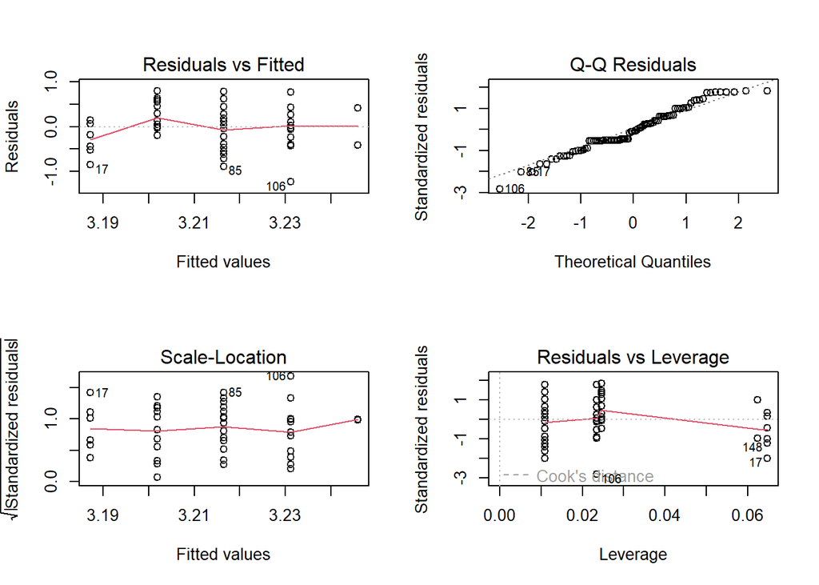

```r
# Model 1
par(mfrow = c(2, 2))
plot(model1)
```

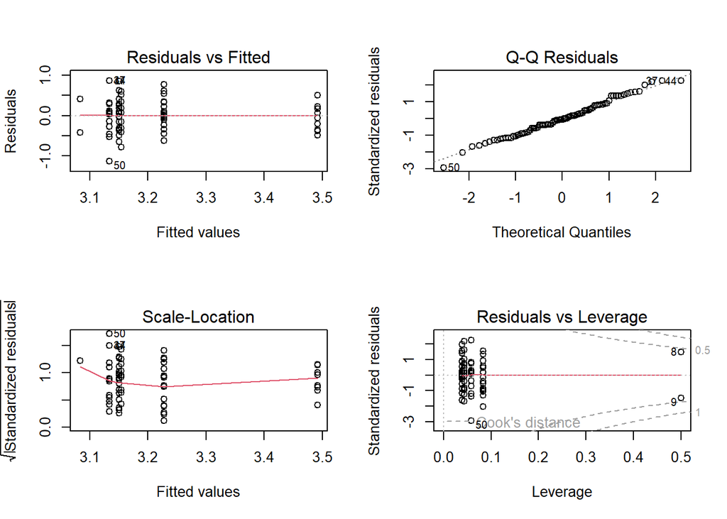

```r
par(mfrow = c(1, 1))  # Reset

# Repeat for others:

par(mfrow = c(2, 2))
plot(model2)
```

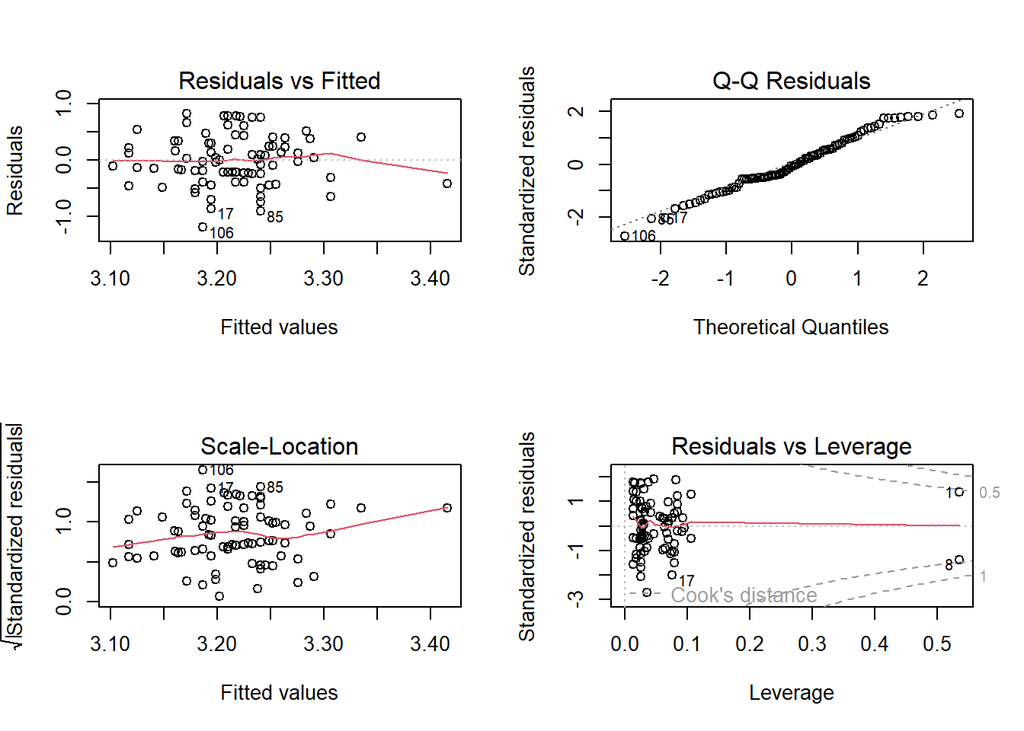

```r
par(mfrow = c(1, 1))  # Reset



par(mfrow = c(2, 2))
plot(model3)
```

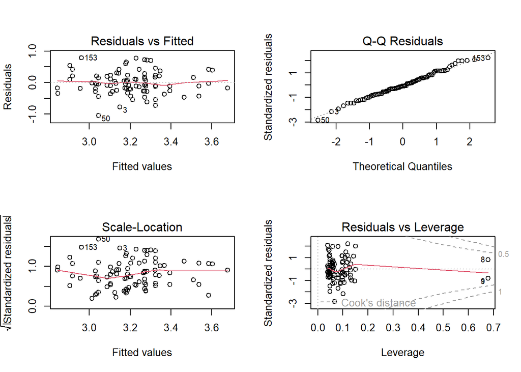

```r
par(mfrow = c(1, 1))  # Reset


par(mfrow = c(2, 2))
plot(model4)
```

```r
par(mfrow = c(1, 1))  # Reset





cat("呀唬")
```

```
呀唬
```

## Reference and Data

Chatbots’ Impact on University Learning https://www.kaggle.com/datasets/jocelyndumlao/chatbots-impact-on-university-learning?resource=download